# Laptop Price Prediction

2023-10-02

Import all the necessary libraries

```r
library(knitr)
library(tidyverse)
library(GGally)
```

```r
library(ggplot2)
library(randomForest)
library(caret)
library(dplyr)
library(corrplot)
library(caTools)
library(caret)
library(e1071)
library(rpart)
library(randomForest)
library(MASS)
library(xgboost)
library(scales)
library(car)
```

Load the laptop dataset

```r
dataset <- read.csv("laptop_data.csv")
kable(head(dataset))
```

| X | Company | TypeName | Inches | ScreenResolution | Cpu | Ram | Memory | Gpu | OpSys | Weight | Price |
| --- | --- | --- | --- | --- | --- | --- | --- | --- | --- | --- | --- |
| 0 | Apple | Ultrabook | 13.3 | IPS Panel Retina Display 2560x1600 | Intel Core i5 2.3GHz | 8GB | 128GB SSD | Intel Iris Plus Graphics 640 | macOS | 1.37kg | 71378.68 |
| 1 | Apple | Ultrabook | 13.3 | 1440x900 | Intel Core i5 1.8GHz | 8GB | 128GB Flash Storage | Intel HD Graphics 6000 | macOS | 1.34kg | 47895.52 |
| 2 | HP | Notebook | 15.6 | Full HD 1920x1080 | Intel Core i5 7200U 2.5GHz | 8GB | 256GB SSD | Intel HD Graphics 620 | No OS | 1.86kg | 30636.00 |
| 3 | Apple | Ultrabook | 15.4 | IPS Panel Retina Display 2880x1800 | Intel Core i7 2.7GHz | 16GB | 512GB SSD | AMD Radeon Pro 455 | macOS | 1.83kg | 135195.34 |
| 4 | Apple | Ultrabook | 13.3 | IPS Panel Retina Display 2560x1600 | Intel Core i5 3.1GHz | 8GB | 256GB SSD | Intel Iris Plus Graphics 650 | macOS | 1.37kg | 96095.81 |
| 5 | Acer | Notebook | 15.6 | 1366x768 | AMD A9-Series 9420 3GHz | 4GB | 500GB HDD | AMD Radeon R5 | Windows 10 | 2.1kg | 21312.00 |

```r
view(dataset)
```

For general information about the dataset

```r
dim(dataset)
```

```
## [1] 1303   12
```

```r
glimpse(dataset)
```

```
## Rows: 1,303
## Columns: 12
## $ X                <int> 0, 1, 2, 3, 4, 5, 6, 7, 8, 9, 10, 11, 12, 13, 14, 15,…
## $ Company          <chr> "Apple", "Apple", "HP", "Apple", "Apple", "Acer", "Ap…
## $ TypeName         <chr> "Ultrabook", "Ultrabook", "Notebook", "Ultrabook", "U…
## $ Inches           <dbl> 13.3, 13.3, 15.6, 15.4, 13.3, 15.6, 15.4, 13.3, 14.0,…
## $ ScreenResolution <chr> "IPS Panel Retina Display 2560x1600", "1440x900", "Fu…
## $ Cpu              <chr> "Intel Core i5 2.3GHz", "Intel Core i5 1.8GHz", "Inte…
## $ Ram              <chr> "8GB", "8GB", "8GB", "16GB", "8GB", "4GB", "16GB", "8…
## $ Memory           <chr> "128GB SSD", "128GB Flash Storage", "256GB SSD", "512…
## $ Gpu              <chr> "Intel Iris Plus Graphics 640", "Intel HD Graphics 60…
## $ OpSys            <chr> "macOS", "macOS", "No OS", "macOS", "macOS", "Windows…
## $ Weight           <chr> "1.37kg", "1.34kg", "1.86kg", "1.83kg", "1.37kg", "2.…
## $ Price            <dbl> 71378.68, 47895.52, 30636.00, 135195.34, 96095.81, 21…
```

To see if there are any duplicate records

```r
cat(sum(duplicated(dataset)))
```

```
## 0
```

Check if there are any null/NA values in our dataset

```r
anyNA(dataset)
```

```
## [1] FALSE
```

Check the first 6 rows of the dataset for general information

```r
kable(head(dataset))
```

| X | Company | TypeName | Inches | ScreenResolution | Cpu | Ram | Memory | Gpu | OpSys | Weight | Price |
| --- | --- | --- | --- | --- | --- | --- | --- | --- | --- | --- | --- |
| 0 | Apple | Ultrabook | 13.3 | IPS Panel Retina Display 2560x1600 | Intel Core i5 2.3GHz | 8GB | 128GB SSD | Intel Iris Plus Graphics 640 | macOS | 1.37kg | 71378.68 |
| 1 | Apple | Ultrabook | 13.3 | 1440x900 | Intel Core i5 1.8GHz | 8GB | 128GB Flash Storage | Intel HD Graphics 6000 | macOS | 1.34kg | 47895.52 |
| 2 | HP | Notebook | 15.6 | Full HD 1920x1080 | Intel Core i5 7200U 2.5GHz | 8GB | 256GB SSD | Intel HD Graphics 620 | No OS | 1.86kg | 30636.00 |
| 3 | Apple | Ultrabook | 15.4 | IPS Panel Retina Display 2880x1800 | Intel Core i7 2.7GHz | 16GB | 512GB SSD | AMD Radeon Pro 455 | macOS | 1.83kg | 135195.34 |
| 4 | Apple | Ultrabook | 13.3 | IPS Panel Retina Display 2560x1600 | Intel Core i5 3.1GHz | 8GB | 256GB SSD | Intel Iris Plus Graphics 650 | macOS | 1.37kg | 96095.81 |
| 5 | Acer | Notebook | 15.6 | 1366x768 | AMD A9-Series 9420 3GHz | 4GB | 500GB HDD | AMD Radeon R5 | Windows 10 | 2.1kg | 21312.00 |

Lets view the statistical analysis of the numerical columns

```r
summary(dataset)
```

```
##        X            Company            TypeName             Inches
##  Min.   :   0.0   Length:1303        Length:1303        Min.   :10.10
##  1st Qu.: 325.5   Class :character   Class :character   1st Qu.:14.00
##  Median : 651.0   Mode  :character   Mode  :character   Median :15.60
##  Mean   : 651.0                                         Mean   :15.02
##  3rd Qu.: 976.5                                         3rd Qu.:15.60
##  Max.   :1302.0                                         Max.   :18.40
##  ScreenResolution       Cpu                Ram               Memory
##  Length:1303        Length:1303        Length:1303        Length:1303
##  Class :character   Class :character   Class :character   Class :character
##  Mode  :character   Mode  :character   Mode  :character   Mode  :character
##
##
##
##      Gpu               OpSys              Weight              Price
##  Length:1303        Length:1303        Length:1303        Min.   :  9271
##  Class :character   Class :character   Class :character   1st Qu.: 31915
##  Mode  :character   Mode  :character   Mode  :character   Median : 52055
##                                                           Mean   : 59870
##                                                           3rd Qu.: 79274
##                                                           Max.   :324955
```

Lets clean the columns RAM and weight becuase they are necessary for our analysis

```r
dataset$Ram <- gsub(pattern = "GB", replacement = "", x = dataset$Ram)
dataset$Weight <- gsub(pattern = "kg", replacement = "", x = dataset$Weight)
```

Changing Ram and weight column into numeric

```r
dataset$Ram <- as.integer(dataset$Ram)
dataset$Weight <- as.double(dataset$Weight)
```

Changing the price column from INR into NPR by applying the exchange rate : 1INR = 1.6 NPR

```r
dataset$Price = dataset$Price * 1.6
```

EDA

lets visualize the distribution of price

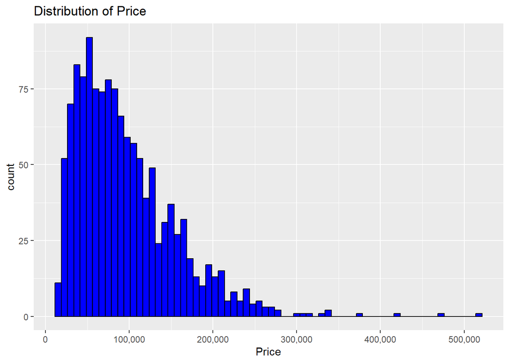

```r
ggplot(data = dataset, aes(x = Price)) +
  geom_histogram(binwidth = 7500, fill = 'blue', color = "black") +
  labs(title = 'Distribution of Price', x = 'Price') +
  scale_x_continuous(labels = scales::comma)
```

Lets see the count plot of the laptop company

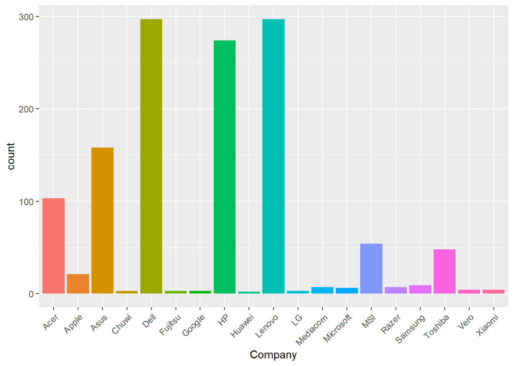

```r
ggplot(data = dataset) +
  geom_bar(mapping = aes(x = Company, fill = Company)) +
  theme(axis.text.x = element_text(angle = 45, hjust = 1)) +
  guides(fill = FALSE)
```

Lets see which company laptops are more expensive

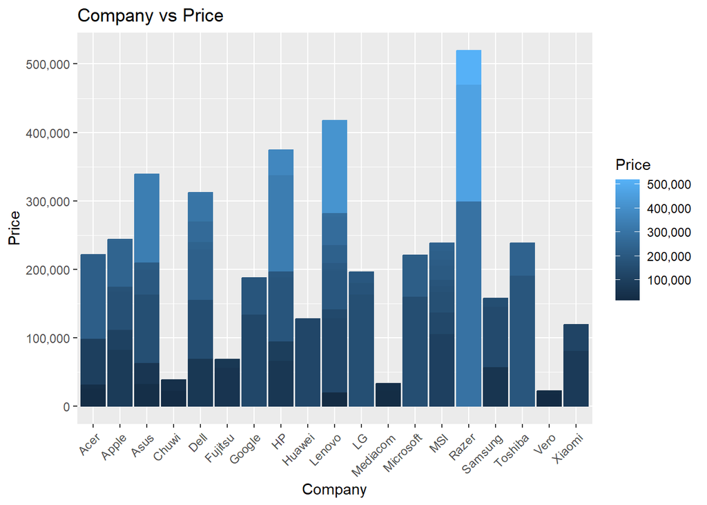

```r
ggplot(dataset,
       aes(x = factor(Company),
           y = Price,
           fill = Price,
           colour = Price)) +
  geom_bar(stat = "identity", position = "dodge") +
  labs(title = "Company vs Price", x = "Company", y="Price")+
  scale_y_continuous(labels = comma) +
  scale_fill_continuous(labels = scales::comma) +
   scale_color_continuous(labels = scales::comma)+
  theme(axis.text.x = element_text(angle = 45, hjust = 1))
```

As we can see from the plot, laptops from Razer are more expensive comparatively

Lets see the types that the laptops can be categorized into

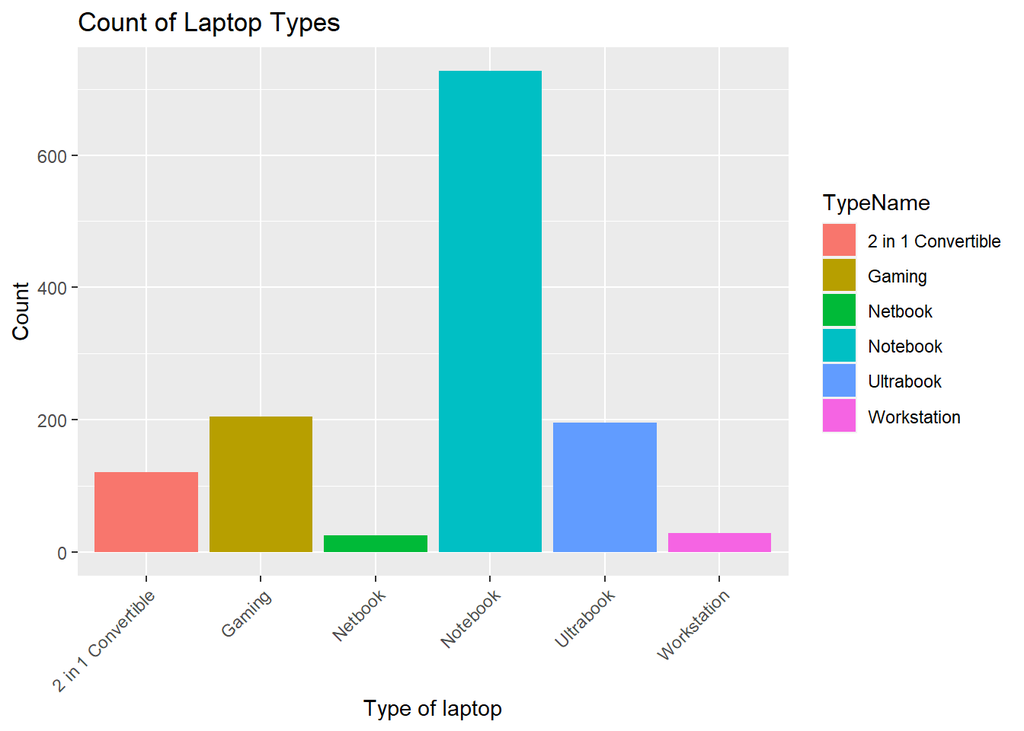

```r
ggplot(dataset, aes(x = TypeName, fill = TypeName)) +
  geom_bar() +
  labs(title = 'Count of Laptop Types', x = 'Type of laptop', y = 'Count') +
  theme(axis.text.x = element_text(angle = 45, hjust = 1))
```

Lets see the price distribution among the types of laptops

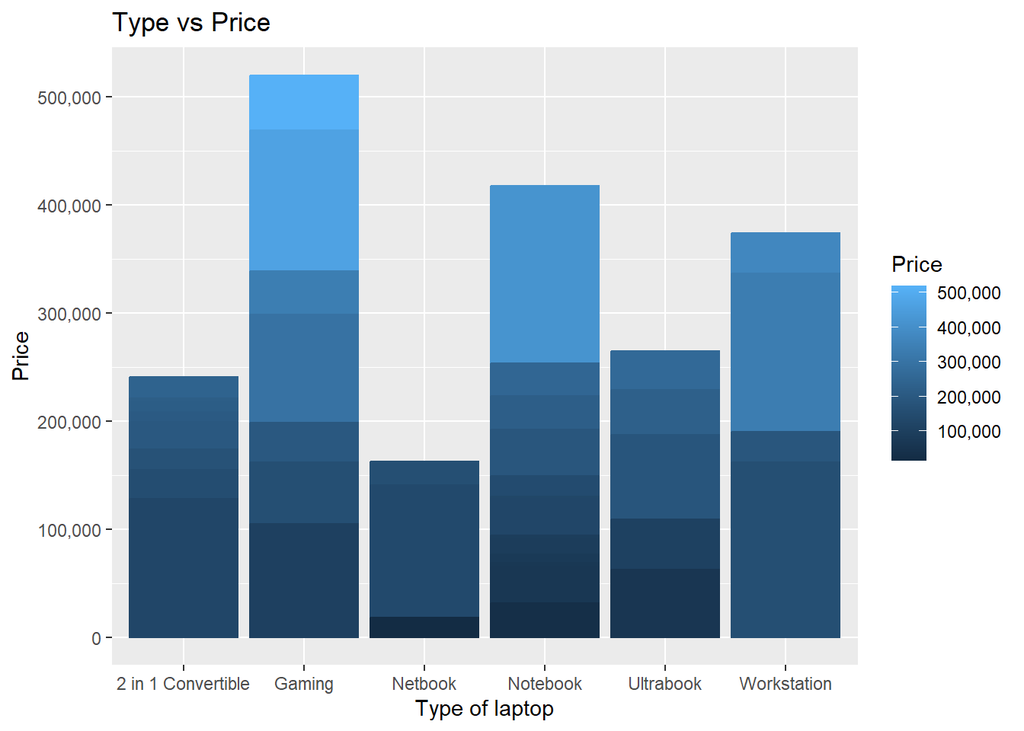

```r
ggplot(dataset, aes(x = factor(TypeName), y = Price, fill = Price, colour = Price)) +
  geom_bar(stat = "identity", position = "dodge") +
  labs(title = "Type vs Price", x = "Type of laptop", y = "Price") +
  scale_y_continuous(labels = comma) +
  scale_fill_continuous(labels = scales::comma) +
   scale_color_continuous(labels = scales::comma)
```

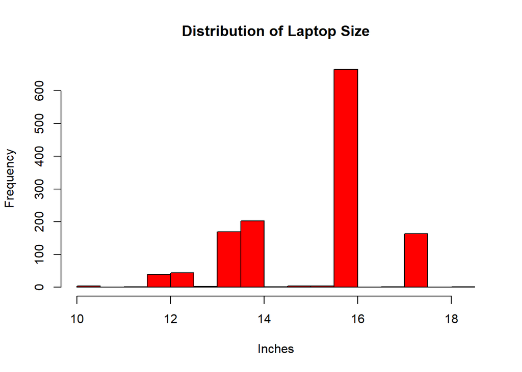

```r
hist(dataset$Inches, main='Distribution of Laptop Size', xlab='Inches', col='red', breaks=12)
```

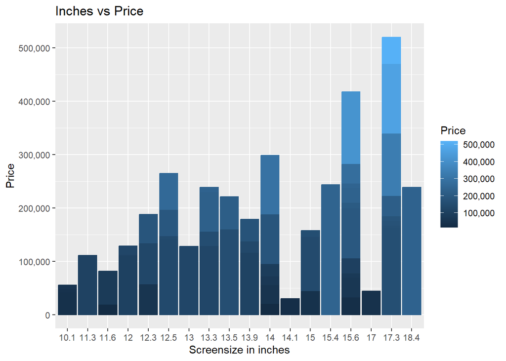

```r
ggplot(dataset, aes(x = factor(Inches), y = Price, fill = Price, colour = Price)) +
  labs(title = "Inches vs Price" ,x = "Screensize in inches", y = "Price") +
  geom_bar(stat = "identity", position = "dodge") +
  scale_y_continuous(labels = scales::comma) +
  scale_fill_continuous(labels = scales::comma) +
   scale_color_continuous(labels = scales::comma)
```

Lets analyse the screen resolution column

```r
sum(duplicated(dataset$ScreenResolution))
```

```
## [1] 1263
```

```r
unique(dataset$ScreenResolution)
```

```
##  [1] "IPS Panel Retina Display 2560x1600"
##  [2] "1440x900"
##  [3] "Full HD 1920x1080"
##  [4] "IPS Panel Retina Display 2880x1800"
##  [5] "1366x768"
##  [6] "IPS Panel Full HD 1920x1080"
##  [7] "IPS Panel Retina Display 2304x1440"
##  [8] "IPS Panel Full HD / Touchscreen 1920x1080"
##  [9] "Full HD / Touchscreen 1920x1080"
## [10] "Touchscreen / Quad HD+ 3200x1800"
## [11] "IPS Panel Touchscreen 1920x1200"
## [12] "Touchscreen 2256x1504"
## [13] "Quad HD+ / Touchscreen 3200x1800"
## [14] "IPS Panel 1366x768"
## [15] "IPS Panel 4K Ultra HD / Touchscreen 3840x2160"
```

[output cut: 25 more lines]

Lets fetch the touchscreen data from the dataset

```r
dataset$touchscreen <- ifelse(grepl("Touchscreen", dataset$ScreenResolution), 1, 0)
```

Visualizing the number of laptops that have touchscreen

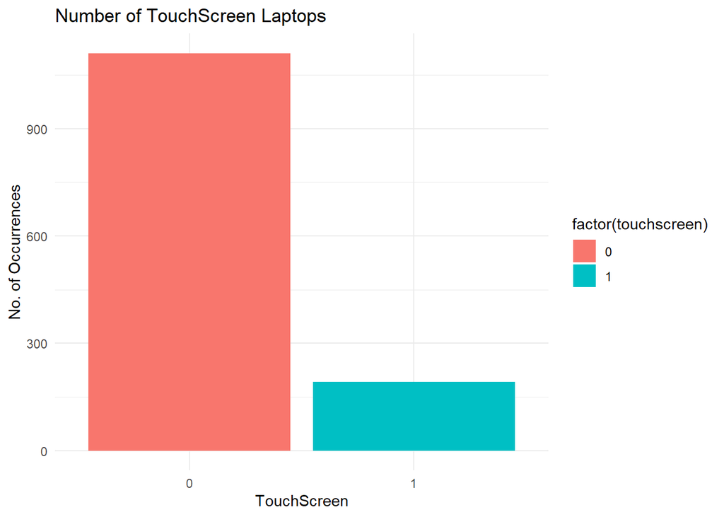

```r
ggplot(dataset, aes(x = factor(touchscreen), fill = factor(touchscreen))) +
  geom_bar() +
  labs(title = 'Number of TouchScreen Laptops', x = 'TouchScreen', y = 'No. of Occurrences') +

  theme_minimal()
```

Lets see the relation between touchscreen and price of the laptop

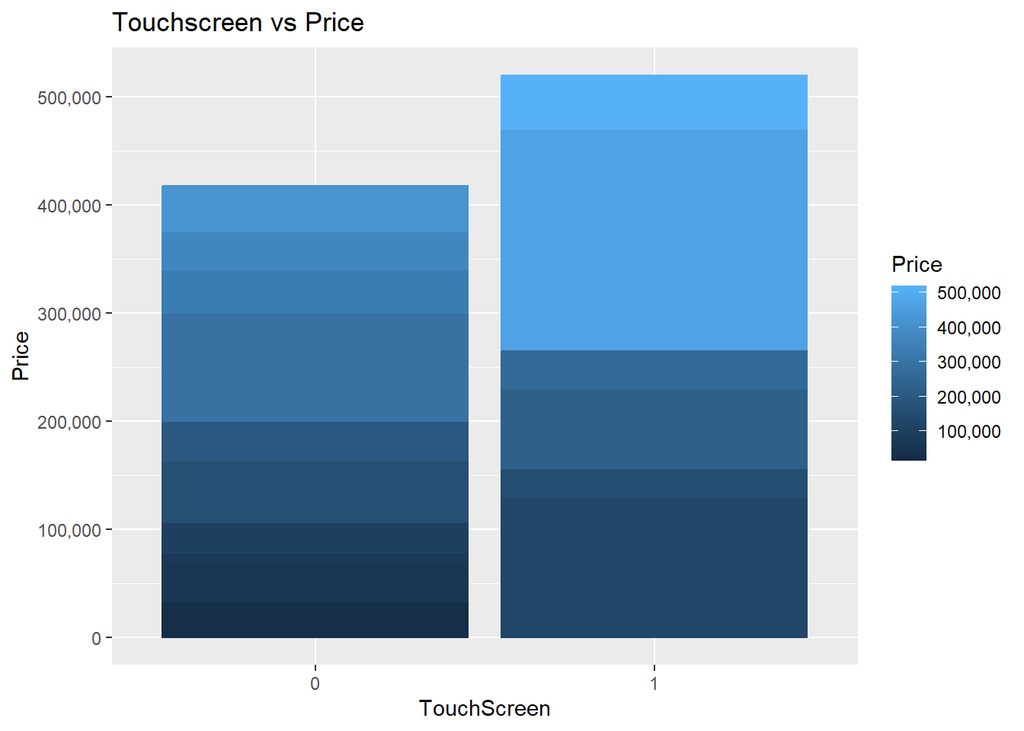

```r
ggplot(dataset, aes(x = factor(touchscreen), y = Price, fill = Price, colour = Price)) +
  geom_bar(stat = "identity", position = "dodge") +
  labs(title= "Touchscreen vs Price", x= "TouchScreen", "Price" )+
  scale_y_continuous(labels = comma) +
  scale_fill_continuous(labels = scales::comma) +
  scale_color_continuous(labels = scales::comma)
```

Lets fetch IPS Panel from the screen resolution column

```r
dataset$IPS <- ifelse(grepl("IPS Panel", dataset$ScreenResolution), 1, 0)
```

Lets visualize the number of laptops with IPS Panel

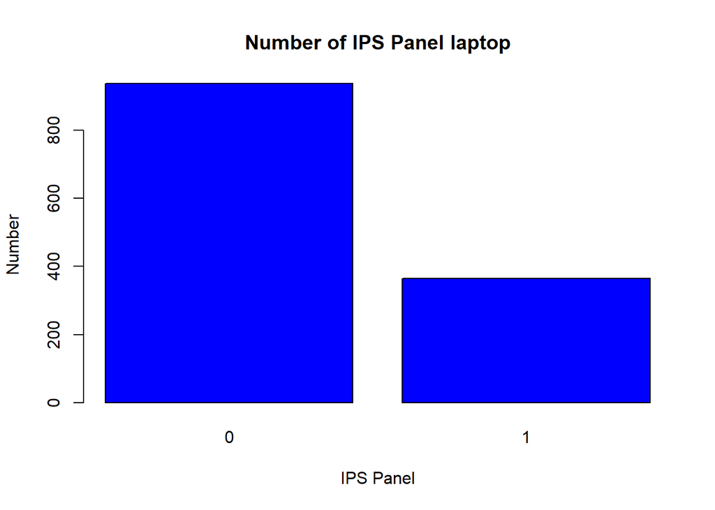

```r
  barplot(table(dataset$IPS),
          main='Number of IPS Panel laptop',
          ylab = "Number",
          xlab = "IPS Panel",
          breaks=12,
          col = "blue")
```

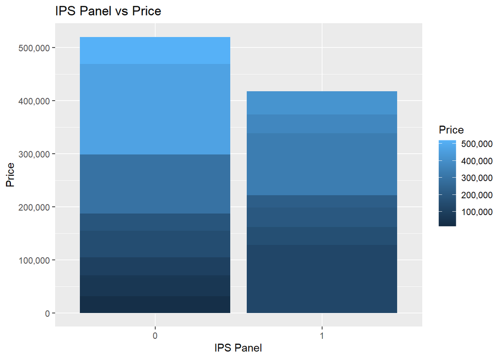

```r
# Relationship between IPS and Price
ggplot(dataset, aes(x = factor(IPS), y = Price, fill = Price)) +
  labs(title = "IPS Panel vs Price", x = "IPS Panel", y = "Price") +
  scale_y_continuous(labels = comma) +
  scale_fill_continuous(labels = scales::comma) +
   scale_color_continuous(labels = scales::comma)+
  geom_bar(stat = "identity", position = "dodge")
```

```r
res <- strsplit(dataset$ScreenResolution, "x", fixed = TRUE)
head(res)
```

```
## [[1]]
## [1] "IPS Panel Retina Display 2560" "1600"
##
## [[2]]
## [1] "1440" "900"
##
## [[3]]
## [1] "Full HD 1920" "1080"
##
## [[4]]
## [1] "IPS Panel Retina Display 2880" "1800"
##
## [[5]]
## [1] "IPS Panel Retina Display 2560" "1600"
##
## [[6]]
## [1] "1366" "768"
```

```r
dataset$X_res <- sapply(res, function(x) x[1])
dataset$Y_res <- sapply(res, function(x) x[2])
head(dataset)
```

```
##   X Company  TypeName Inches                   ScreenResolution
## 1 0   Apple Ultrabook   13.3 IPS Panel Retina Display 2560x1600
## 2 1   Apple Ultrabook   13.3                           1440x900
## 3 2      HP  Notebook   15.6                  Full HD 1920x1080
## 4 3   Apple Ultrabook   15.4 IPS Panel Retina Display 2880x1800
## 5 4   Apple Ultrabook   13.3 IPS Panel Retina Display 2560x1600
## 6 5    Acer  Notebook   15.6                           1366x768
##                          Cpu Ram              Memory
## 1       Intel Core i5 2.3GHz   8           128GB SSD
## 2       Intel Core i5 1.8GHz   8 128GB Flash Storage
## 3 Intel Core i5 7200U 2.5GHz   8           256GB SSD
## 4       Intel Core i7 2.7GHz  16           512GB SSD
## 5       Intel Core i5 3.1GHz   8           256GB SSD
## 6    AMD A9-Series 9420 3GHz   4           500GB HDD
##                            Gpu      OpSys Weight     Price touchscreen IPS
## 1 Intel Iris Plus Graphics 640      macOS   1.37 114205.89           0   1
## 2       Intel HD Graphics 6000      macOS   1.34  76632.84           0   0
## 3        Intel HD Graphics 620      No OS   1.86  49017.60           0   0
## 4           AMD Radeon Pro 455      macOS   1.83 216312.54           0   1
## 5 Intel Iris Plus Graphics 650      macOS   1.37 153753.29           0   1
## 6                AMD Radeon R5 Windows 10   2.10  34099.20           0   0
##                           X_res Y_res
## 1 IPS Panel Retina Display 2560  1600
## 2                          1440   900
## 3                  Full HD 1920  1080
## 4 IPS Panel Retina Display 2880  1800
## 5 IPS Panel Retina Display 2560  1600
## 6                          1366   768
```

```r
dataset$X_res <- gsub(",", "", dataset$X_res)
dataset$X_res <- as.numeric(regmatches(dataset$X_res, regexpr("\\d+\\.?\\d+", dataset$X_res)))
glimpse(dataset)
```

```
## Rows: 1,303
## Columns: 16
## $ X                <int> 0, 1, 2, 3, 4, 5, 6, 7, 8, 9, 10, 11, 12, 13, 14, 15,…
## $ Company          <chr> "Apple", "Apple", "HP", "Apple", "Apple", "Acer", "Ap…
## $ TypeName         <chr> "Ultrabook", "Ultrabook", "Notebook", "Ultrabook", "U…
## $ Inches           <dbl> 13.3, 13.3, 15.6, 15.4, 13.3, 15.6, 15.4, 13.3, 14.0,…
## $ ScreenResolution <chr> "IPS Panel Retina Display 2560x1600", "1440x900", "Fu…
## $ Cpu              <chr> "Intel Core i5 2.3GHz", "Intel Core i5 1.8GHz", "Inte…
## $ Ram              <int> 8, 8, 8, 16, 8, 4, 16, 8, 16, 8, 4, 4, 16, 4, 8, 8, 8…
## $ Memory           <chr> "128GB SSD", "128GB Flash Storage", "256GB SSD", "512…
## $ Gpu              <chr> "Intel Iris Plus Graphics 640", "Intel HD Graphics 60…
## $ OpSys            <chr> "macOS", "macOS", "No OS", "macOS", "macOS", "Windows…
## $ Weight           <dbl> 1.37, 1.34, 1.86, 1.83, 1.37, 2.10, 2.04, 1.34, 1.30,…
## $ Price            <dbl> 114205.89, 76632.84, 49017.60, 216312.54, 153753.29, …
## $ touchscreen      <dbl> 0, 0, 0, 0, 0, 0, 0, 0, 0, 0, 0, 0, 0, 0, 0, 0, 0, 0,…
## $ IPS              <dbl> 1, 0, 0, 1, 1, 0, 1, 0, 0, 1, 0, 0, 1, 0, 1, 1, 0, 1,…
## $ X_res            <dbl> 2560, 1440, 1920, 2880, 2560, 1366, 2880, 1440, 1920,…
## $ Y_res            <chr> "1600", "900", "1080", "1800", "1600", "768", "1800",…
```

```r
# X and Y res are char dtype so need to convert into numeric dtype
dataset$Y_res <- as.numeric(dataset$Y_res)
glimpse(dataset)
```

```
## Rows: 1,303
## Columns: 16
## $ X                <int> 0, 1, 2, 3, 4, 5, 6, 7, 8, 9, 10, 11, 12, 13, 14, 15,…
## $ Company          <chr> "Apple", "Apple", "HP", "Apple", "Apple", "Acer", "Ap…
## $ TypeName         <chr> "Ultrabook", "Ultrabook", "Notebook", "Ultrabook", "U…
## $ Inches           <dbl> 13.3, 13.3, 15.6, 15.4, 13.3, 15.6, 15.4, 13.3, 14.0,…
## $ ScreenResolution <chr> "IPS Panel Retina Display 2560x1600", "1440x900", "Fu…
## $ Cpu              <chr> "Intel Core i5 2.3GHz", "Intel Core i5 1.8GHz", "Inte…
## $ Ram              <int> 8, 8, 8, 16, 8, 4, 16, 8, 16, 8, 4, 4, 16, 4, 8, 8, 8…
## $ Memory           <chr> "128GB SSD", "128GB Flash Storage", "256GB SSD", "512…
## $ Gpu              <chr> "Intel Iris Plus Graphics 640", "Intel HD Graphics 60…
## $ OpSys            <chr> "macOS", "macOS", "No OS", "macOS", "macOS", "Windows…
## $ Weight           <dbl> 1.37, 1.34, 1.86, 1.83, 1.37, 2.10, 2.04, 1.34, 1.30,…
## $ Price            <dbl> 114205.89, 76632.84, 49017.60, 216312.54, 153753.29, …
## $ touchscreen      <dbl> 0, 0, 0, 0, 0, 0, 0, 0, 0, 0, 0, 0, 0, 0, 0, 0, 0, 0,…
## $ IPS              <dbl> 1, 0, 0, 1, 1, 0, 1, 0, 0, 1, 0, 0, 1, 0, 1, 1, 0, 1,…
## $ X_res            <dbl> 2560, 1440, 1920, 2880, 2560, 1366, 2880, 1440, 1920,…
## $ Y_res            <dbl> 1600, 900, 1080, 1800, 1600, 768, 1800, 900, 1080, 10…
```

```r
# we can see that inches do not have a strong correlation, but X and Y-axis resolution do,
# so we can take advantage of this and convert these three columns to a single column
# known as Pixel per inches (PPI).
dataset$ppi <- (((dataset$X_res^2) + (dataset$Y_res^2))^0.5) / as.numeric(dataset$Inches)
```

```r
# Drop the extra columns which are not helpful our price prediction
# X','X_res', 'Y_res', 'Inches', 'ScreenResolution'
dataset <- dataset[, !(names(dataset) %in% c('X','X_res', 'Y_res', 'Inches', 'ScreenResolution'))]
glimpse(dataset)
```

```
## Rows: 1,303
## Columns: 12
## $ Company     <chr> "Apple", "Apple", "HP", "Apple", "Apple", "Acer", "Apple",…
## $ TypeName    <chr> "Ultrabook", "Ultrabook", "Notebook", "Ultrabook", "Ultrab…
## $ Cpu         <chr> "Intel Core i5 2.3GHz", "Intel Core i5 1.8GHz", "Intel Cor…
## $ Ram         <int> 8, 8, 8, 16, 8, 4, 16, 8, 16, 8, 4, 4, 16, 4, 8, 8, 8, 16,…
## $ Memory      <chr> "128GB SSD", "128GB Flash Storage", "256GB SSD", "512GB SS…
## $ Gpu         <chr> "Intel Iris Plus Graphics 640", "Intel HD Graphics 6000", …
## $ OpSys       <chr> "macOS", "macOS", "No OS", "macOS", "macOS", "Windows 10",…
## $ Weight      <dbl> 1.37, 1.34, 1.86, 1.83, 1.37, 2.10, 2.04, 1.34, 1.30, 1.60…
## $ Price       <dbl> 114205.89, 76632.84, 49017.60, 216312.54, 153753.29, 34099…
## $ touchscreen <dbl> 0, 0, 0, 0, 0, 0, 0, 0, 0, 0, 0, 0, 0, 0, 0, 0, 0, 0, 0, 1…
## $ IPS         <dbl> 1, 0, 0, 1, 1, 0, 1, 0, 0, 1, 0, 0, 1, 0, 1, 1, 0, 1, 0, 1…
## $ ppi         <dbl> 226.9830, 127.6779, 141.2120, 220.5346, 226.9830, 100.4547…
```

```r
# Now, CPU column, does it affect Price?
unique(dataset$Cpu)
```

```
##   [1] "Intel Core i5 2.3GHz"
##   [2] "Intel Core i5 1.8GHz"
##   [3] "Intel Core i5 7200U 2.5GHz"
##   [4] "Intel Core i7 2.7GHz"
##   [5] "Intel Core i5 3.1GHz"
##   [6] "AMD A9-Series 9420 3GHz"
##   [7] "Intel Core i7 2.2GHz"
##   [8] "Intel Core i7 8550U 1.8GHz"
##   [9] "Intel Core i5 8250U 1.6GHz"
##  [10] "Intel Core i3 6006U 2GHz"
##  [11] "Intel Core i7 2.8GHz"
##  [12] "Intel Core M m3 1.2GHz"
##  [13] "Intel Core i7 7500U 2.7GHz"
##  [14] "Intel Core i7 2.9GHz"
##  [15] "Intel Core i3 7100U 2.4GHz"
```

[output cut: 103 more lines]

```r
dataset$CpuName <- sapply(dataset$Cpu, function(x) {
  words <- unlist(strsplit(x, " "))
  if (length(words) >= 3) {
    paste0(words[1:3], collapse = " ")
  } else {
    paste0(words, collapse = " ")  # Use all available words if less than 3
  }
})
```

```r
fetch_processor <- function(text) {
  if (text == 'Intel Core i7' || text == 'Intel Core i5' || text == 'Intel Core i3') {
    return(text)
  } else {
    if (strsplit(text, " ")[[1]][1] == 'Intel') {
      return('Other Intel Processor')
    } else {
      return('AMD Processor')
    }
  }
}
```

```r
dataset$Cpu_brand <- sapply(dataset$CpuName, fetch_processor)
```

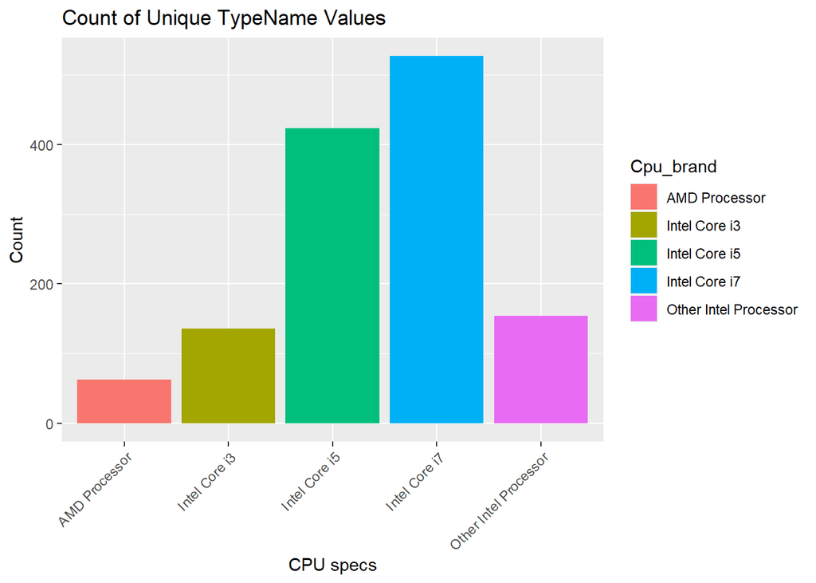

```r
#barplot(table(dataset$Cpu_brand), main='Number of CPU brand',ylab = "Count",xlab = "CPU brand", col='blue', breaks=12)
# Intel i7 and i5 are the most in the dataset.
ggplot(dataset, aes(x = Cpu_brand, fill = Cpu_brand)) +
  geom_bar() +
  labs(title = 'Count of Unique TypeName Values', x = 'CPU specs', y = 'Count') +
  theme(axis.text.x = element_text(angle = 45, hjust = 1))
```

```r
table(dataset$Cpu_brand)
```

```
##
##         AMD Processor         Intel Core i3         Intel Core i5
##                    63                   136                   423
##         Intel Core i7 Other Intel Processor
##                   527                   154
```

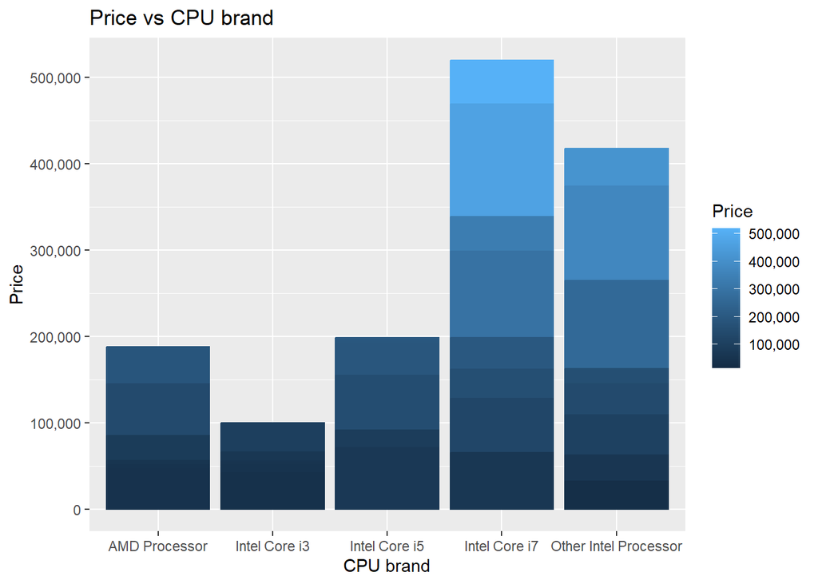

```r
# Will price vary based on cpu processor?

# Relationship between Cpu brand and Price
ggplot(dataset, aes(x = factor(Cpu_brand), y = Price, fill = Price, colour = Price)) +
  geom_bar(stat = "identity", position = "dodge") +
  labs(title = "Price vs CPU brand", x = "CPU brand", y = "Price")+
  scale_y_continuous(labels = comma) +
  scale_fill_continuous(labels = scales::comma) +
   scale_color_continuous(labels = scales::comma)
```

```r
# As, Intel Core i7 have high price than i5,i3,AMD processor.
# Also, the AMD and i5 have almost same range of Price.
# So, we can say, Price will vary according to Cpu processor.
```

```r
# Drop Cpu and Cpu Name column
dataset <- dataset[, !(names(dataset) %in% c('Cpu', 'CpuName'))]
glimpse(dataset)
```

```
## Rows: 1,303
## Columns: 12
## $ Company     <chr> "Apple", "Apple", "HP", "Apple", "Apple", "Acer", "Apple",…
## $ TypeName    <chr> "Ultrabook", "Ultrabook", "Notebook", "Ultrabook", "Ultrab…
## $ Ram         <int> 8, 8, 8, 16, 8, 4, 16, 8, 16, 8, 4, 4, 16, 4, 8, 8, 8, 16,…
## $ Memory      <chr> "128GB SSD", "128GB Flash Storage", "256GB SSD", "512GB SS…
## $ Gpu         <chr> "Intel Iris Plus Graphics 640", "Intel HD Graphics 6000", …
## $ OpSys       <chr> "macOS", "macOS", "No OS", "macOS", "macOS", "Windows 10",…
## $ Weight      <dbl> 1.37, 1.34, 1.86, 1.83, 1.37, 2.10, 2.04, 1.34, 1.30, 1.60…
## $ Price       <dbl> 114205.89, 76632.84, 49017.60, 216312.54, 153753.29, 34099…
## $ touchscreen <dbl> 0, 0, 0, 0, 0, 0, 0, 0, 0, 0, 0, 0, 0, 0, 0, 0, 0, 0, 0, 1…
## $ IPS         <dbl> 1, 0, 0, 1, 1, 0, 1, 0, 0, 1, 0, 0, 1, 0, 1, 1, 0, 1, 0, 1…
## $ ppi         <dbl> 226.9830, 127.6779, 141.2120, 220.5346, 226.9830, 100.4547…
## $ Cpu_brand   <chr> "Intel Core i5", "Intel Core i5", "Intel Core i5", "Intel …
```

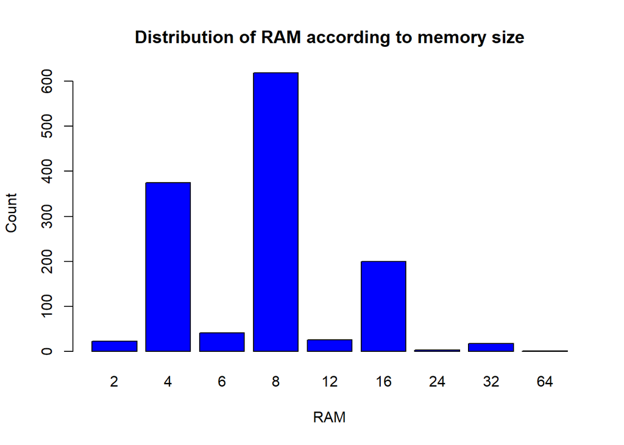

```r
# What about RAM vs Price?

barplot(table(dataset$Ram), main='Distribution of RAM according to memory size',ylab = "Count",xlab = "RAM", col='blue', breaks=12)
```

```r
# Laptop with 8 GB rams are the most in the dataset.
```

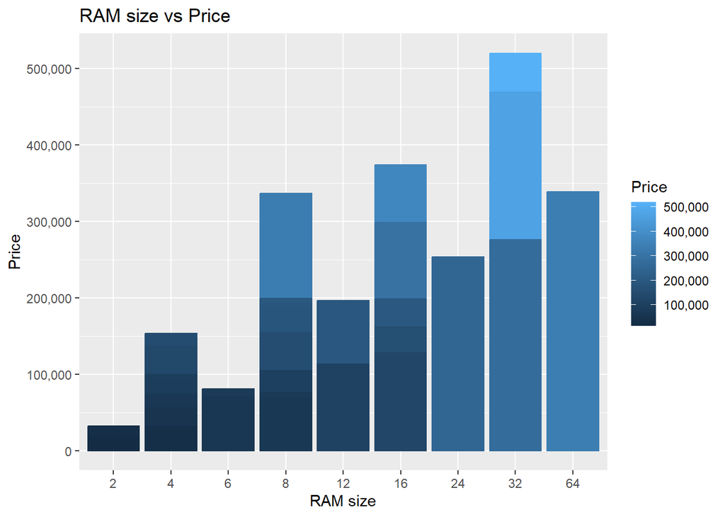

```r
# Relationship between Price and RAM
ggplot(dataset, aes(x = factor(Ram), y = Price, fill = Price, colour = Price)) +
  geom_bar(stat = "identity", position = "dodge")+
  labs(title = "RAM size vs Price",x= "RAM size", y = "Price")+
  scale_y_continuous(labels = comma) +
  scale_fill_continuous(labels = scales::comma) +
  scale_color_continuous(labels = scales::comma)
```

```r
# here, we can see 64 GB RAM price less than 32 GB RAM.
# So, size of high RAM doesn't mean high price.
```

```r
head(dataset$Memory)
```

```
## [1] "128GB SSD"           "128GB Flash Storage" "256GB SSD"
## [4] "512GB SSD"           "256GB SSD"           "500GB HDD"
```

```r
# dataset$Memory # lots of information
unique(dataset$Memory) # what are the unique one - 39 chan
```

```
##  [1] "128GB SSD"                     "128GB Flash Storage"
##  [3] "256GB SSD"                     "512GB SSD"
##  [5] "500GB HDD"                     "256GB Flash Storage"
##  [7] "1TB HDD"                       "32GB Flash Storage"
##  [9] "128GB SSD +  1TB HDD"          "256GB SSD +  256GB SSD"
## [11] "64GB Flash Storage"            "256GB SSD +  1TB HDD"
## [13] "256GB SSD +  2TB HDD"          "32GB SSD"
## [15] "2TB HDD"                       "64GB SSD"
## [17] "1.0TB Hybrid"                  "512GB SSD +  1TB HDD"
## [19] "1TB SSD"                       "256GB SSD +  500GB HDD"
## [21] "128GB SSD +  2TB HDD"          "512GB SSD +  512GB SSD"
## [23] "16GB SSD"                      "16GB Flash Storage"
## [25] "512GB SSD +  256GB SSD"        "512GB SSD +  2TB HDD"
## [27] "64GB Flash Storage +  1TB HDD" "180GB SSD"
## [29] "1TB HDD +  1TB HDD"            "32GB HDD"
## [31] "1TB SSD +  1TB HDD"            "512GB Flash Storage"
## [33] "128GB HDD"                     "240GB SSD"
## [35] "8GB SSD"                       "508GB Hybrid"
## [37] "1.0TB HDD"                     "512GB SSD +  1.0TB Hybrid"
## [39] "256GB SSD +  1.0TB Hybrid"
```

```r
table(dataset$Memory) # value count
```

```
##
##                     1.0TB HDD                  1.0TB Hybrid
##                             1                             9
##           128GB Flash Storage                     128GB HDD
##                             4                             1
##                     128GB SSD          128GB SSD +  1TB HDD
##                            76                            94
##          128GB SSD +  2TB HDD            16GB Flash Storage
##                             2                             7
##                      16GB SSD                     180GB SSD
##                             3                             5
##                       1TB HDD            1TB HDD +  1TB HDD
##                           223                             1
##                       1TB SSD            1TB SSD +  1TB HDD
##                            14                             2
##                     240GB SSD           256GB Flash Storage
##                             1                             8
##                     256GB SSD     256GB SSD +  1.0TB Hybrid
##                           412                             1
##          256GB SSD +  1TB HDD        256GB SSD +  256GB SSD
##                            73                             2
##          256GB SSD +  2TB HDD        256GB SSD +  500GB HDD
##                            10                             2
##                       2TB HDD            32GB Flash Storage
##                            16                            38
##                      32GB HDD                      32GB SSD
##                             1                             6
##                     500GB HDD                  508GB Hybrid
##                           132                             1
##           512GB Flash Storage                     512GB SSD
##                             2                           118
##     512GB SSD +  1.0TB Hybrid          512GB SSD +  1TB HDD
##                             1                            14
##        512GB SSD +  256GB SSD          512GB SSD +  2TB HDD
##                             1                             3
##        512GB SSD +  512GB SSD            64GB Flash Storage
##                             1                            15
## 64GB Flash Storage +  1TB HDD                      64GB SSD
##                             1                             1
##                       8GB SSD
##                             1
```

```r
# Feature Engineering

# many categories and some only have 1 (difficult to prediction)
# some with both ssd and hdd, some have only ssd, some have hybrid, flash storage.
# so, we separate the value in 4 column - 1. Hard drive 2. SSD 3. Flash Storage, 4. Hybrid

dataset$Memory <- gsub("\\.0", "", as.character(dataset$Memory))
dataset$Memory <- gsub("GB", "", dataset$Memory)
dataset$Memory <- gsub("TB", "000", dataset$Memory)
```

```r
dataset = dataset %>%
  separate(Memory, into = c("first", "second"), sep = "\\+", fill = "right") %>%
  mutate(first = str_trim(first),
         second = str_trim(second))
```

```r
# Indicator variable for each column

dataset = dataset %>%
  mutate(Layer1HDD = if_else(str_detect(first, "HDD"), 1, 0),
         Layer1SSD = if_else(str_detect(first, "SSD"), 1, 0),
         Layer1Hybrid = if_else(str_detect(first, "Hybrid"), 1, 0),
         Layer1Flash_Storage = if_else(str_detect(first, "Flash Storage"), 1, 0),
         first = as.integer(gsub("\\D", "", first)),
         second = as.integer(gsub("\\D", "", second)),
         second = if_else(is.na(second), 0, second),
         Layer2HDD = if_else(str_detect(second, "HDD"), 1, 0),
         Layer2SSD = if_else(str_detect(second, "SSD"), 1, 0),
         Layer2Hybrid = if_else(str_detect(second, "Hybrid"), 1, 0),
         Layer2Flash_Storage = if_else(str_detect(second, "Flash Storage"), 1, 0))

view(dataset)
head(dataset)
```

```
##   Company  TypeName Ram first second                          Gpu      OpSys
## 1   Apple Ultrabook   8   128      0 Intel Iris Plus Graphics 640      macOS
## 2   Apple Ultrabook   8   128      0       Intel HD Graphics 6000      macOS
## 3      HP  Notebook   8   256      0        Intel HD Graphics 620      No OS
## 4   Apple Ultrabook  16   512      0           AMD Radeon Pro 455      macOS
## 5   Apple Ultrabook   8   256      0 Intel Iris Plus Graphics 650      macOS
## 6    Acer  Notebook   4   500      0                AMD Radeon R5 Windows 10
##   Weight     Price touchscreen IPS      ppi     Cpu_brand Layer1HDD Layer1SSD
## 1   1.37 114205.89           0   1 226.9830 Intel Core i5         0         1
## 2   1.34  76632.84           0   0 127.6779 Intel Core i5         0         0
## 3   1.86  49017.60           0   0 141.2120 Intel Core i5         0         1
## 4   1.83 216312.54           0   1 220.5346 Intel Core i7         0         1
## 5   1.37 153753.29           0   1 226.9830 Intel Core i5         0         1
## 6   2.10  34099.20           0   0 100.4547 AMD Processor         1         0
##   Layer1Hybrid Layer1Flash_Storage Layer2HDD Layer2SSD Layer2Hybrid
## 1            0                   0         0         0            0
## 2            0                   1         0         0            0
## 3            0                   0         0         0            0
## 4            0                   0         0         0            0
## 5            0                   0         0         0            0
## 6            0                   0         0         0            0
##   Layer2Flash_Storage
## 1                   0
## 2                   0
## 3                   0
## 4                   0
## 5                   0
## 6                   0
```

```r
# Calculate HDD, SDD, Hybrid and Flash_Storage
dataset = dataset %>%
  mutate(HDD = first * Layer1HDD + second * Layer2HDD,
         SSD = first * Layer1SSD + second * Layer2SSD,
         Hybrid = first * Layer1Hybrid + second * Layer2Hybrid,
         Flash_Storage = first * Layer1Flash_Storage + second * Layer2Flash_Storage)
```

```r
# remove unneccesary column for our dataset
dataset = subset(dataset, select = -c(first, second, Layer1HDD, Layer1SSD, Layer1Hybrid, Layer1Flash_Storage, Layer2HDD, Layer2SSD, Layer2Hybrid, Layer2Flash_Storage))
```

```r
column_to_compare <- dataset$Price
correlations <- sapply(dataset[sapply(dataset, is.numeric)], function(x) cor(x, column_to_compare))
correlations
```

```
##           Ram        Weight         Price   touchscreen           IPS
##    0.74300714    0.21036980    1.00000000    0.19122646    0.25220762
##           ppi           HDD           SSD        Hybrid Flash_Storage
##    0.47348731   -0.38042846    0.67620241   -0.04014748   -0.04051115
```

```r
# If we see correlation of Price with Hybrid and Flash_Stroage doesn't have less correlation.
# So, we drop this two column

dataset <- dataset[, !(names(dataset) %in% c("Hybrid","Flash_Storage"))]
view(dataset)
```

```r
# GPU Column
table(dataset$Gpu)
```

```
##
##             AMD FirePro W4190M            AMD FirePro W4190M
##                              1                              2
##             AMD FirePro W5130M             AMD FirePro W6150M
##                              1                              1
##                 AMD R17M-M1-70                AMD R4 Graphics
##                              1                              1
##                 AMD Radeon 520                 AMD Radeon 530
##                             17                             41
##                 AMD Radeon 540             AMD Radeon Pro 455
##                              1                              1
##             AMD Radeon Pro 555             AMD Radeon Pro 560
##                              1                              1
##                  AMD Radeon R2         AMD Radeon R2 Graphics
##                              5                              4
##                  AMD Radeon R3                  AMD Radeon R4
##                              1                              3
##         AMD Radeon R4 Graphics                  AMD Radeon R5
##                              5                             11
##              AMD Radeon R5 430              AMD Radeon R5 520
##                              1                              1
##             AMD Radeon R5 M315             AMD Radeon R5 M330
##                              1                              7
##             AMD Radeon R5 M420            AMD Radeon R5 M420X
##                              8                              3
##             AMD Radeon R5 M430                  AMD Radeon R7
##                             22                              1
##         AMD Radeon R7 Graphics             AMD Radeon R7 M360
##                              1                              1
##            AMD Radeon R7 M365X             AMD Radeon R7 M440
##                              1                              5
##             AMD Radeon R7 M445             AMD Radeon R7 M460
##                             14                              2
##             AMD Radeon R7 M465             AMD Radeon R9 M385
##                              1                              1
##              AMD Radeon RX 540              AMD Radeon RX 550
##                              2                              4
##              AMD Radeon RX 560              AMD Radeon RX 580
##                              1                              5
##              ARM Mali T860 MP4             Intel Graphics 620
```

[output cut: 56 more lines]

```
##                              1                              1
##           Nvidia GeForce MX130           Nvidia GeForce MX150
##                              6                             15
##             Nvidia GTX 980 SLI            Nvidia Quadro 3000M
##                              1                              1
##           Nvidia Quadro M1000M            Nvidia Quadro M1200
##                              4                              9
##           Nvidia Quadro M2000M            Nvidia Quadro M2200
##                              2                              2
##           Nvidia Quadro M2200M           Nvidia Quadro M3000M
##                              3                              1
##            Nvidia Quadro M500M            Nvidia Quadro M520M
##                              1                              2
##             Nvidia Quadro M620            Nvidia Quadro M620M
##                              5                              1
```

```r
# Many different graphics card information, but we only select brand name of
# particular graphics card
```

```r
dataset$Gpubrand <- sapply(dataset$Gpu, function(x) {strsplit(x, " ")[[1]][1]})
table(dataset$Gpubrand)
```

```
##
##    AMD    ARM  Intel Nvidia
##    180      1    722    400
```

```r
dataset <- dataset[dataset$`Gpubrand` != 'ARM', ] # we don't need GPU ARM only brand name.
table(dataset$Gpubrand)
```

```
##
##    AMD  Intel Nvidia
##    180    722    400
```

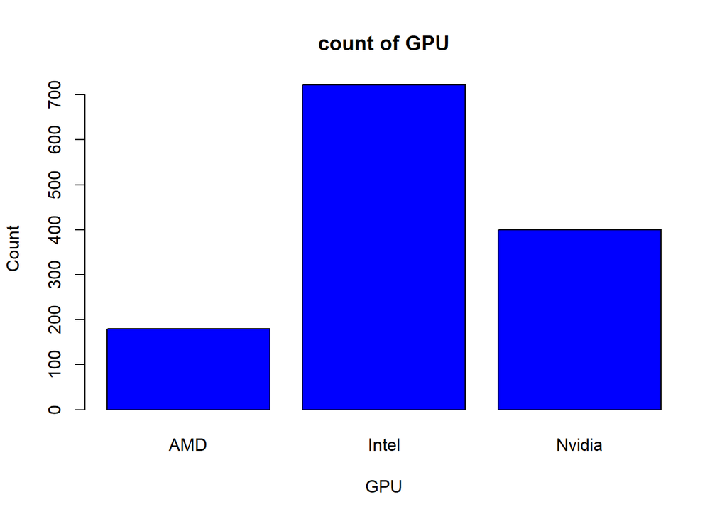

```r
barplot(table(dataset$Gpubrand), main='count of GPU',ylab = "Count",xlab = "GPU", col='blue', breaks=12)
```

```r
# Intel GPU are most in dataset.
```

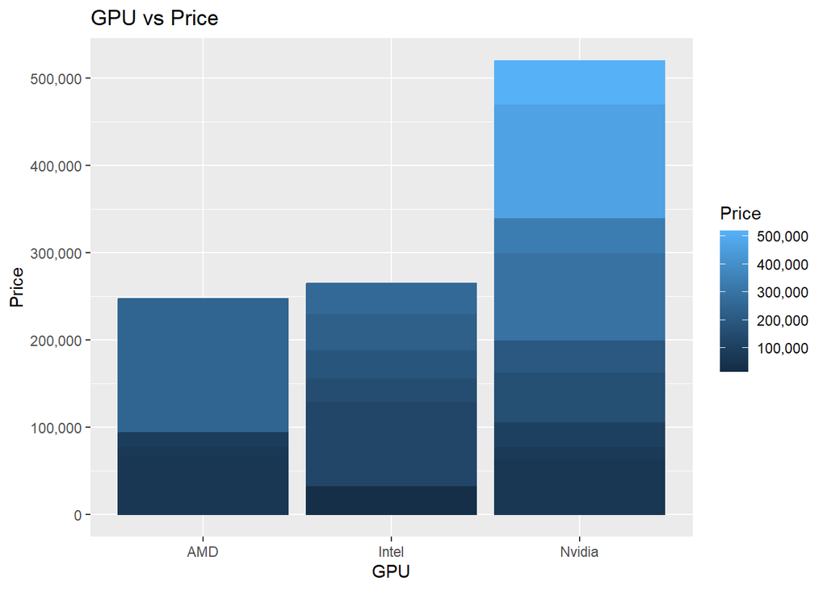

```r
# Relationship between GPU and Price
ggplot(dataset, aes(x = factor(Gpubrand), y = Price, fill = Price, colour = Price)) +
  geom_bar(stat = "identity", position = "dodge")+
  labs(title = "GPU vs Price",x="GPU", y = "Price")+
  scale_y_continuous(labels = comma) +
  scale_fill_continuous(labels = scales::comma) +
  scale_color_continuous(labels = scales::comma)
```

```r
# Nvidia GPU are much expansive than Intel and AMD
```

```r
# Drop GPU column
dataset <- dataset[, !(names(dataset) %in% c('Gpu'))]
head(dataset)
```

```
##   Company  TypeName Ram      OpSys Weight     Price touchscreen IPS      ppi
## 1   Apple Ultrabook   8      macOS   1.37 114205.89           0   1 226.9830
## 2   Apple Ultrabook   8      macOS   1.34  76632.84           0   0 127.6779
## 3      HP  Notebook   8      No OS   1.86  49017.60           0   0 141.2120
## 4   Apple Ultrabook  16      macOS   1.83 216312.54           0   1 220.5346
## 5   Apple Ultrabook   8      macOS   1.37 153753.29           0   1 226.9830
## 6    Acer  Notebook   4 Windows 10   2.10  34099.20           0   0 100.4547
##       Cpu_brand HDD SSD Gpubrand
## 1 Intel Core i5   0 128    Intel
## 2 Intel Core i5   0   0    Intel
## 3 Intel Core i5   0 256    Intel
## 4 Intel Core i7   0 512      AMD
## 5 Intel Core i5   0 256    Intel
## 6 AMD Processor 500   0      AMD
```

```r
# Operating System

table(dataset$OpSys)
```

```
##
##      Android    Chrome OS        Linux     Mac OS X        macOS        No OS
##            2           26           62            8           13           66
##   Windows 10 Windows 10 S    Windows 7
##         1072            8           45
```

```r
# we can see, there is Mac OS x, MacOs | Windows 10 , Windows 10s
# To make easy, we keep all Mac categories at one, same to windows
cat_os <- function(os) {
  if (os == 'Windows 10' || os == 'Windows 7' || os == 'Windows 10 S') {
    return('Windows')
  } else if (os == 'Mac OS X' || os == 'macOS') {
    return('Mac')
  } else {
    return('others/NO OS/Linux')
  }
}
```

```r
dataset$OS <- sapply(dataset$OpSys, cat_os)
head(dataset)
```

```
##   Company  TypeName Ram      OpSys Weight     Price touchscreen IPS      ppi
## 1   Apple Ultrabook   8      macOS   1.37 114205.89           0   1 226.9830
## 2   Apple Ultrabook   8      macOS   1.34  76632.84           0   0 127.6779
## 3      HP  Notebook   8      No OS   1.86  49017.60           0   0 141.2120
## 4   Apple Ultrabook  16      macOS   1.83 216312.54           0   1 220.5346
## 5   Apple Ultrabook   8      macOS   1.37 153753.29           0   1 226.9830
## 6    Acer  Notebook   4 Windows 10   2.10  34099.20           0   0 100.4547
##       Cpu_brand HDD SSD Gpubrand                 OS
## 1 Intel Core i5   0 128    Intel                Mac
## 2 Intel Core i5   0   0    Intel                Mac
## 3 Intel Core i5   0 256    Intel others/NO OS/Linux
## 4 Intel Core i7   0 512      AMD                Mac
## 5 Intel Core i5   0 256    Intel                Mac
## 6 AMD Processor 500   0      AMD            Windows
```

```r
table(dataset$OS)
```

```
##
##                Mac others/NO OS/Linux            Windows
##                 21                156               1125
```

```r
# Drop OpSys column
dataset <- dataset[, !(names(dataset) %in% c('OpSys'))]
head(dataset)
```

```
##   Company  TypeName Ram Weight     Price touchscreen IPS      ppi     Cpu_brand
## 1   Apple Ultrabook   8   1.37 114205.89           0   1 226.9830 Intel Core i5
## 2   Apple Ultrabook   8   1.34  76632.84           0   0 127.6779 Intel Core i5
## 3      HP  Notebook   8   1.86  49017.60           0   0 141.2120 Intel Core i5
## 4   Apple Ultrabook  16   1.83 216312.54           0   1 220.5346 Intel Core i7
## 5   Apple Ultrabook   8   1.37 153753.29           0   1 226.9830 Intel Core i5
## 6    Acer  Notebook   4   2.10  34099.20           0   0 100.4547 AMD Processor
##   HDD SSD Gpubrand                 OS
## 1   0 128    Intel                Mac
## 2   0   0    Intel                Mac
## 3   0 256    Intel others/NO OS/Linux
## 4   0 512      AMD                Mac
## 5   0 256    Intel                Mac
## 6 500   0      AMD            Windows
```

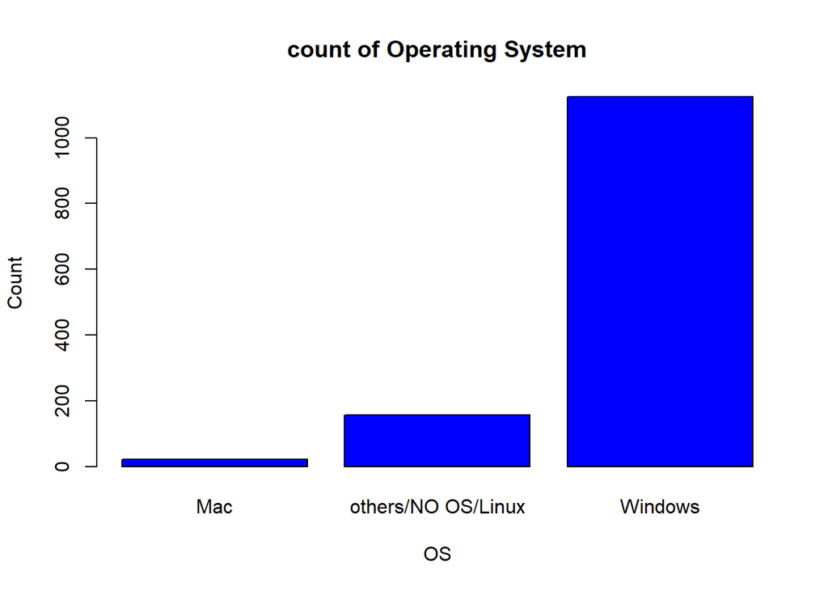

```r
barplot(table(dataset$OS), main='count of Operating System',ylab = "Count",xlab = "OS", col='blue', breaks=12)
```

```r
# Intel GPU are most in dataset.
```

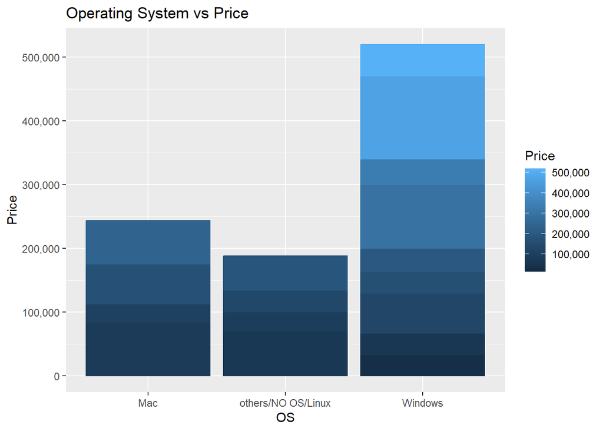

```r
# Relationship between OS and Price
ggplot(dataset, aes(x = factor(OS), y = Price, fill = Price, colour = Price)) +
  geom_bar(stat = "identity", position = "dodge")+
  labs(title = "Operating System vs Price", x = "OS", y = "Price")+
  scale_y_continuous(labels = comma) +
  scale_fill_continuous(labels = scales::comma) +
   scale_color_continuous(labels = scales::comma)
```

```r
# windows laptop are more expansive compare to other's
```

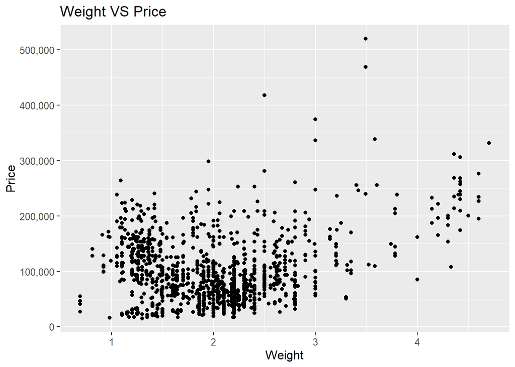

```r
# Relationship btn Weight and Price
ggplot(dataset, aes(x = Weight, y = Price)) +
  geom_point() +
  labs(x = "Weight", y = "Price", title = "Weight VS Price") +
  theme(text = element_text(size = 12))+
  scale_y_continuous(labels = comma) +
  scale_fill_continuous(labels = scales::comma) +
   scale_color_continuous(labels = scales::comma)
```